# SignificantResults

Dhaen Alkaabi Aidan Pierre-Louis Luke Marini Noah Eisenberg

2023-12-05

#### https://github.com/nflverse/nflverse-data

# Research Question 1.1: Do draft pick number and various player draft performance attributes, such as rushing yards, recieving yards, and defensive sacks exhibit a significant correlation towards a player’s success in the NFL and draft? And if so, which positions have the strongest and weakest correlations?

```r
#Data Cleaning and Wrangling

draft_data_clean <- draft_data %>%
  select(season, pick, position, rush_yards, rec_yards, def_sacks) %>%
  mutate(season = as.numeric(season)) %>%
  filter(!is.na(pick)) %>%
  na.omit()
```

> The first segment of the code is dedicated to preparing the dataset for analysis. It focuses on selecting the relevant columns, converting the season to a numeric format, filtering out rows with missing pick values, and removing rows with any NA values. This step is crucial as it lays the foundation for accurate and meaningful analysis. By ensuring the data is clean and relevant, this process directly supports the investigation of the research question, particularly in examining the relationship between draft pick numbers and player success metrics. Clean and well-structured data is vital for deriving valid conclusions about how draft picks relate to player performance in the NFL.

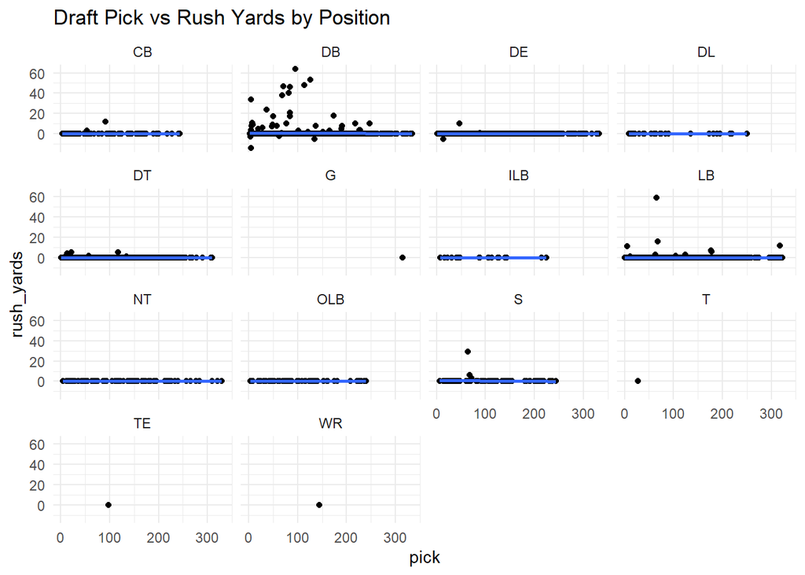

```r
#Data Visualization

ggplot(draft_data_clean, aes(x = pick, y = rush_yards)) +
  geom_point() +
  geom_smooth(method = "lm") +
  facet_wrap(~position) +
  theme_minimal() +
  labs(title = "Draft Pick vs Rush Yards by Position")
```

> This code creates a scatter plot with a linear regression line to visually explore the relationship between the draft pick number (pick) and rushing yards (rush_yards), one of the success metrics. It also uses facet_wrap to separate the plots by player position, allowing for an easy comparison across different roles. This visualization is integral to understanding the correlation between draft pick number and player success, specifically how this relationship might vary across different positions. It provides a clear visual representation to address the first part of the research question, focusing on the significance of the correlation between draft pick number, player success metrics, and variations across different positions.

```r
#Statistical Modeling: Correlation and Regression Analysis

cor_pick_rush <- cor.test(draft_data_clean$pick, draft_data_clean$rush_yards, use = "complete.obs")
cor_pick_rec <- cor.test(draft_data_clean$pick, draft_data_clean$rec_yards, use = "complete.obs")
cor_pick_def_sacks <- cor.test(draft_data_clean$pick, draft_data_clean$def_sacks, use = "complete.obs")

# Print the results of the correlation tests
print(paste("Correlation between draft pick and rushing yards: ", cor_pick_rush$estimate))
```

```
## [1] "Correlation between draft pick and rushing yards:  -0.0175121709702713"
```

```r
print(paste("P-value:", cor_pick_rush$p.value))
```

```
## [1] "P-value: 0.331423658886743"
```

```r
print(paste("Correlation between draft pick and receiving yards: ", cor_pick_rec$estimate))
```

```
## [1] "Correlation between draft pick and receiving yards:  -0.00937572810801893"
```

```r
print(paste("P-value:", cor_pick_rec$p.value))
```

```
## [1] "P-value: 0.603089383032102"
```

```r
print(paste("Correlation between draft pick and defensive sacks: ", cor_pick_def_sacks$estimate))
```

```
## [1] "Correlation between draft pick and defensive sacks:  -0.253237778219403"
```

```r
print(paste("P-value:", cor_pick_def_sacks$p.value))
```

```
## [1] "P-value: 3.03581030220344e-46"
```

```r
# Fit a linear regression model for rush yards vs draft pick
model_rush_yards <- lm(rush_yards ~ pick, data = draft_data_clean)

# Print the summary of the regression model
summary(model_rush_yards)
```

```
##
## Call:
## lm(formula = rush_yards ~ pick, data = draft_data_clean)
##
## Residuals:
##     Min      1Q  Median      3Q     Max
## -14.321  -0.296  -0.262  -0.214  63.740
##
## Coefficients:
##               Estimate Std. Error t value Pr(>|t|)
## (Intercept)  0.3240416  0.0899454   3.603  0.00032 ***
## pick        -0.0006777  0.0006977  -0.971  0.33142
## ---
## Signif. codes:  0 '***' 0.001 '**' 0.01 '*' 0.05 '.' 0.1 ' ' 1
##
## Residual standard error: 2.912 on 3076 degrees of freedom
## Multiple R-squared:  0.0003067,  Adjusted R-squared:  -1.832e-05
## F-statistic: 0.9436 on 1 and 3076 DF,  p-value: 0.3314
```

> The correlation tests show a very weak negative correlation between draft pick number and both rushing and receiving yards, which is not statistically significant. However, there is a moderate and statistically significant negative correlation between draft pick number and defensive sacks. The linear regression model for predicting rushing yards from the draft pick number is not statistically significant and explains none of the variability in rushing yards.

> The analysis directly addresses the research question by examining if the draft pick number correlates with measurable success in the NFL, such as rushing yards, receiving yards, and defensive sacks. While a significant negative correlation with defensive sacks suggests that lower draft picks (which are considered more premier) tend to perform better in this metric, the lack of significant correlations with rushing and receiving yards implies that the draft pick number may not be a consistent predictor of success for these metrics across various positions. This indicates that other player attributes might also need to be considered to fully assess a player’s potential success in the NFL.

# Research Question 1.2: Do various player attributes, such as height, weight, and speed, exhibit a significant correlation towards a player’s success in the draft pick order? And if so, which positions have the strongest and weakest correlations?

```r
merge_attrs = merge_data %>% filter(!is.na(pick)) %>%
  select(season, round, pick, team, pfr_player_name, position, age, ht, wt, forty, bench, vertical, broad_jump, cone, shuttle)
```

```r
attr_plot <- function(attr) {
merge_attrs %>% ggplot(aes(x= pick,y= attr)) +
  geom_point() +
  geom_smooth()
}

attrs <- list(age, ht, wt, forty, bench, vertical, broad_jump, cone, shuttle)
attr_plots = lapply(attrs, attr_plot)
```

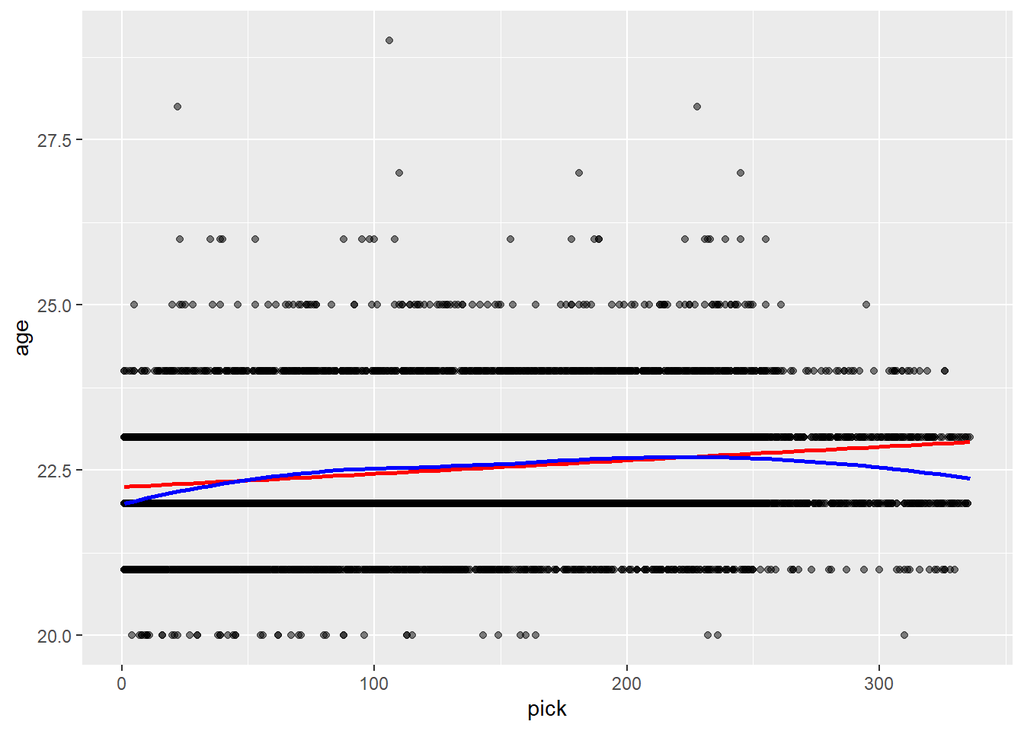

```r
merge_attrs %>% filter(!is.na(age)) %>% ggplot(aes(x= pick,y= age)) +
  geom_point(alpha=0.5) +
  geom_smooth(se=FALSE,method="lm",color="red") + geom_smooth(se=FALSE,method="loess",color="blue")
```

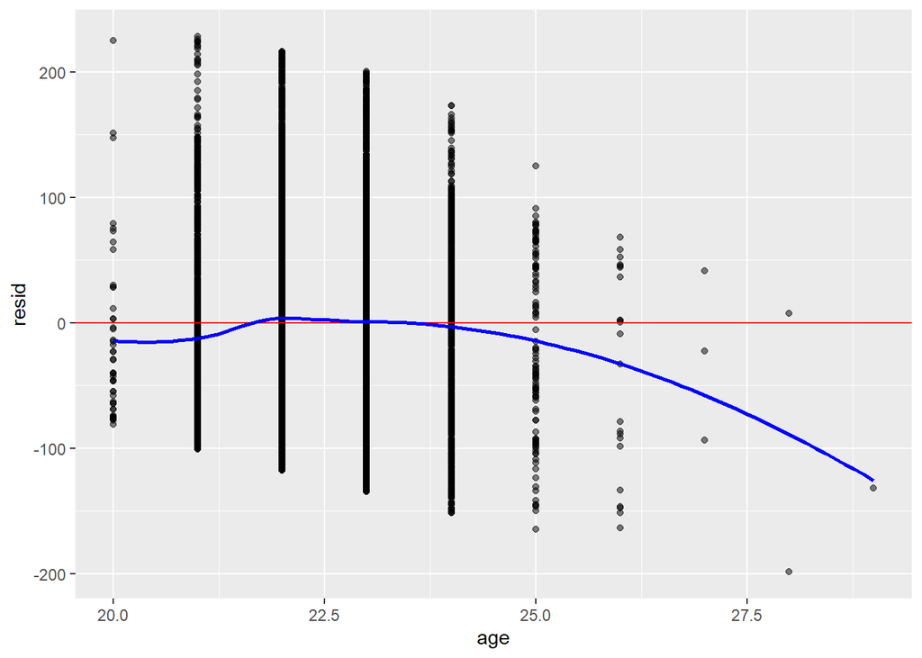

```r
age_lm = lm(pick ~ age,data=merge_attrs %>% filter(!is.na(age)))
merge_attrs %>% filter(!is.na(age)) %>%
  add_residuals(age_lm) %>%
  add_predictions(age_lm) %>%
  ggplot(aes(x= age,y=resid)) +
  geom_point(alpha=0.5) +
  geom_hline(yintercept = 0, color="red") +
  geom_smooth(se=FALSE,method="loess",color="blue")
```

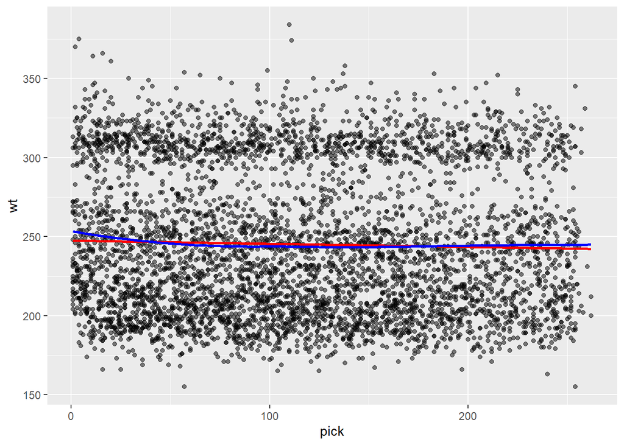

```r
merge_attrs %>% filter(!is.na(wt)) %>% ggplot(aes(x= pick,y= wt)) +
  geom_point(alpha=0.5) +
  geom_smooth(se=FALSE,method="lm",color="red") + geom_smooth(se=FALSE,method="loess",color="blue")
```

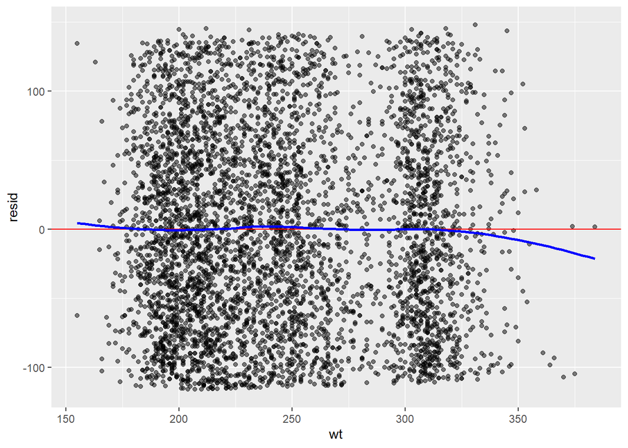

```r
wt_lm = lm(pick ~ wt,data=merge_attrs %>% filter(!is.na(wt)))
merge_attrs %>% filter(!is.na(wt)) %>%
  add_residuals(wt_lm) %>%
  add_predictions(wt_lm) %>%
  ggplot(aes(x= wt,y=resid)) +
  geom_point(alpha=0.5) +
  geom_hline(yintercept = 0, color="red") +
  geom_smooth(se=FALSE,method="loess",color="blue")
```

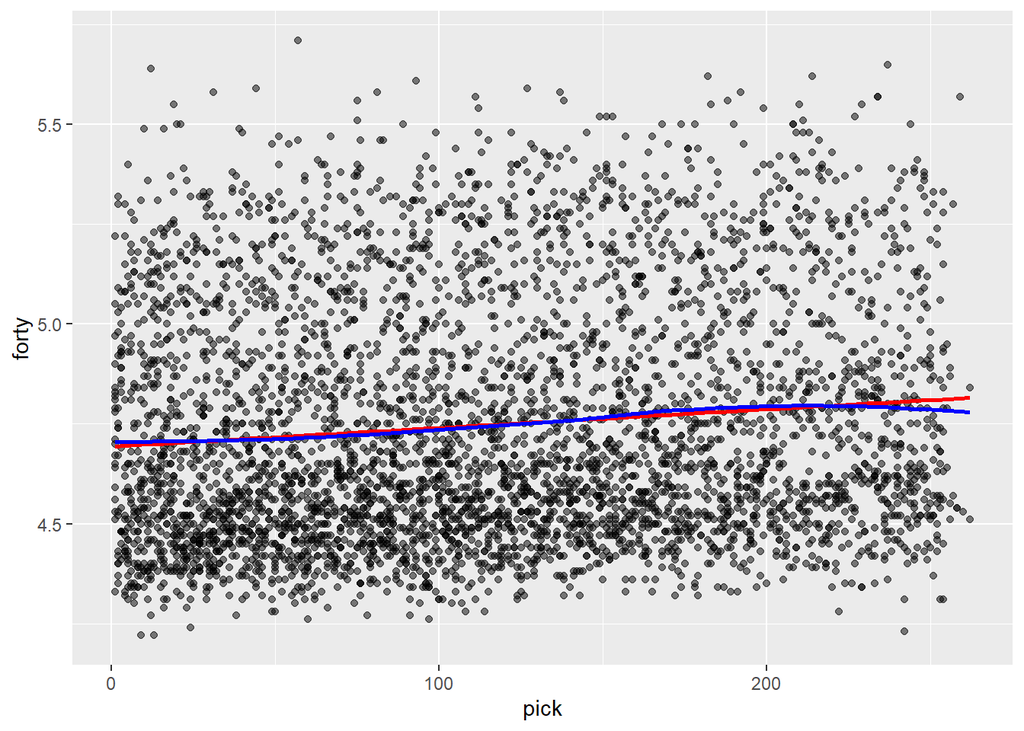

```r
merge_attrs %>% filter(!is.na(forty)) %>% ggplot(aes(x= pick,y= forty)) +
  geom_point(alpha=0.5) +
  geom_smooth(se=FALSE,method="lm",color="red") + geom_smooth(se=FALSE,method="loess",color="blue")
```

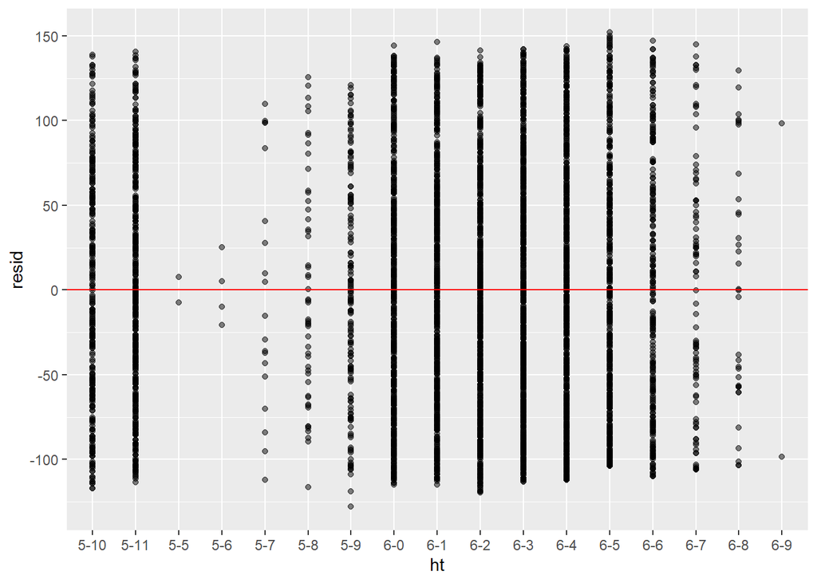

```r
ht_lm = lm(pick ~ ht,data=merge_attrs %>% filter(!is.na(ht)))
merge_attrs %>% filter(!is.na(ht)) %>%
  add_residuals(ht_lm) %>%
  add_predictions(ht_lm) %>%
  ggplot(aes(x= ht,y=resid)) +
  geom_point(alpha=0.5) +
  geom_hline(yintercept = 0, color="red") +
  geom_smooth(se=FALSE,method="loess",color="blue")
```

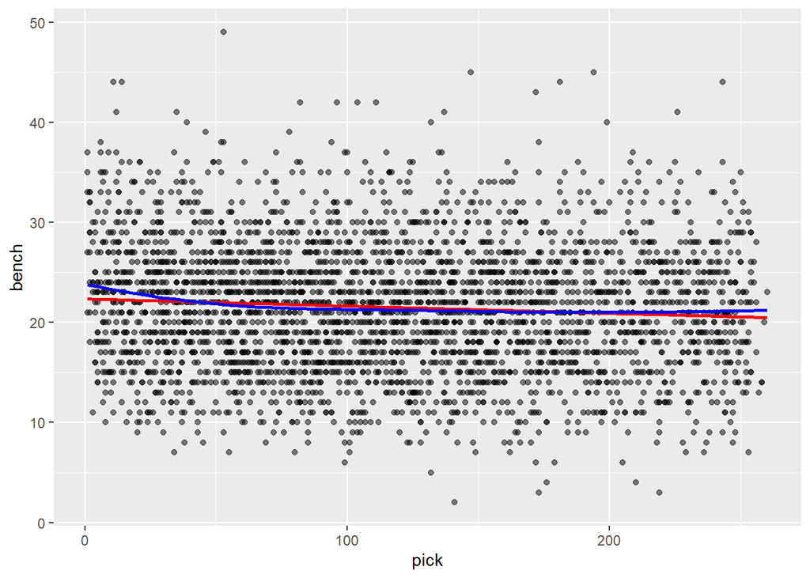

```r
merge_attrs %>% filter(!is.na(bench)) %>% ggplot(aes(x= pick,y= bench)) +
  geom_point(alpha=0.5) +
  geom_smooth(se=FALSE,method="lm",color="red") + geom_smooth(se=FALSE,method="loess",color="blue")
```

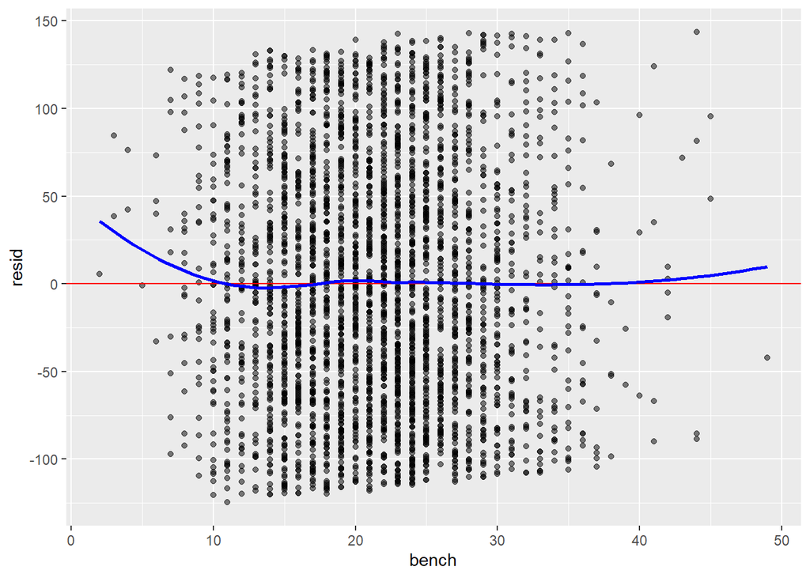

```r
bench_lm = lm(pick ~ bench,data=merge_attrs %>% filter(!is.na(bench)))
merge_attrs %>% filter(!is.na(bench)) %>%
  add_residuals(bench_lm) %>%
  add_predictions(bench_lm) %>%
  ggplot(aes(x= bench,y=resid)) +
  geom_point(alpha=0.5) +
  geom_hline(yintercept = 0, color="red") +
  geom_smooth(se=FALSE,method="loess",color="blue")
```

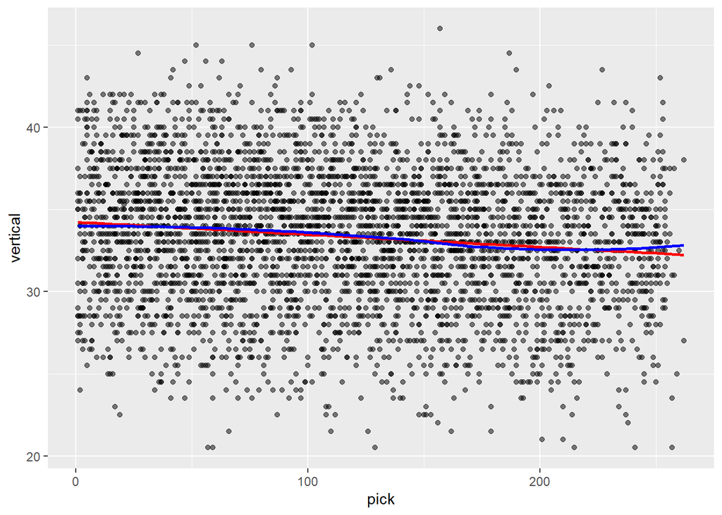

```r
merge_attrs %>% filter(!is.na(vertical)) %>% ggplot(aes(x= pick,y= vertical)) +
  geom_point(alpha=0.5) +
  geom_smooth(se=FALSE,method="lm",color="red") + geom_smooth(se=FALSE,method="loess",color="blue")
```

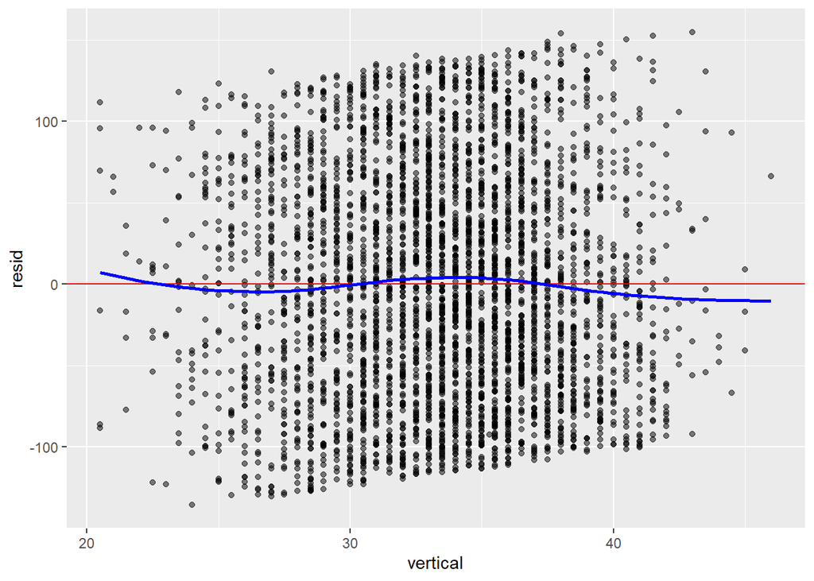

```r
v_lm = lm(pick ~ vertical,data=merge_attrs %>% filter(!is.na(vertical)))
merge_attrs %>% filter(!is.na(vertical)) %>%
  add_residuals(v_lm) %>%
  add_predictions(v_lm) %>%
  ggplot(aes(x= vertical,y=resid)) +
  geom_point(alpha=0.5) +
  geom_hline(yintercept = 0, color="red") +
  geom_smooth(se=FALSE,method="loess",color="blue")
```

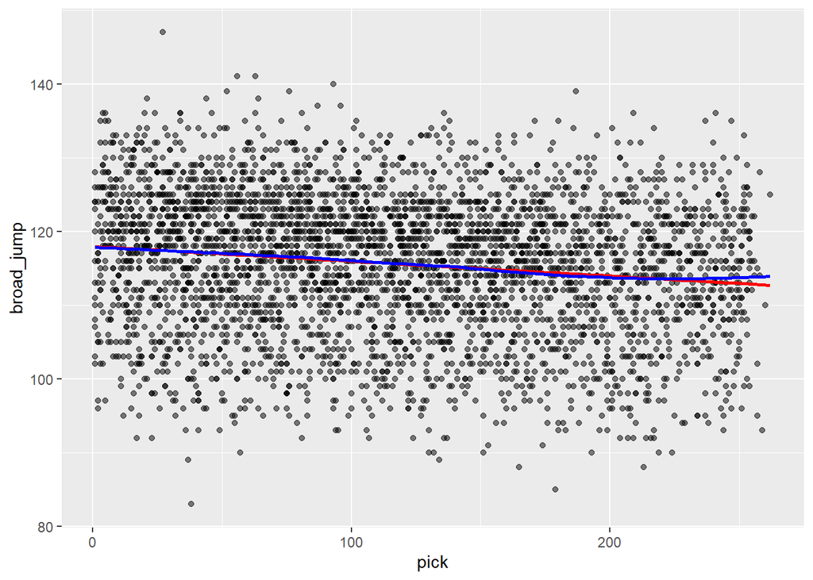

```r
merge_attrs %>% filter(!is.na(broad_jump)) %>% ggplot(aes(x= pick,y= broad_jump)) +
  geom_point(alpha=0.5) +
  geom_smooth(se=FALSE,method="lm",color="red") + geom_smooth(se=FALSE,method="loess",color="blue")
```

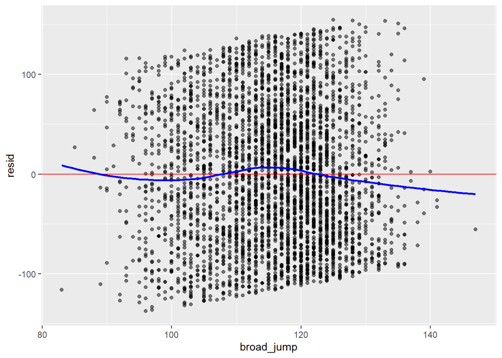

```r
bj_lm = lm(pick ~ broad_jump,data=merge_attrs %>% filter(!is.na(broad_jump)))
merge_attrs %>% filter(!is.na(broad_jump)) %>%
  add_residuals(bj_lm) %>%
  add_predictions(bj_lm) %>%
  ggplot(aes(x= broad_jump,y=resid)) +
  geom_point(alpha=0.5) +
  geom_hline(yintercept = 0, color="red") +
  geom_smooth(se=FALSE,method="loess",color="blue")
```

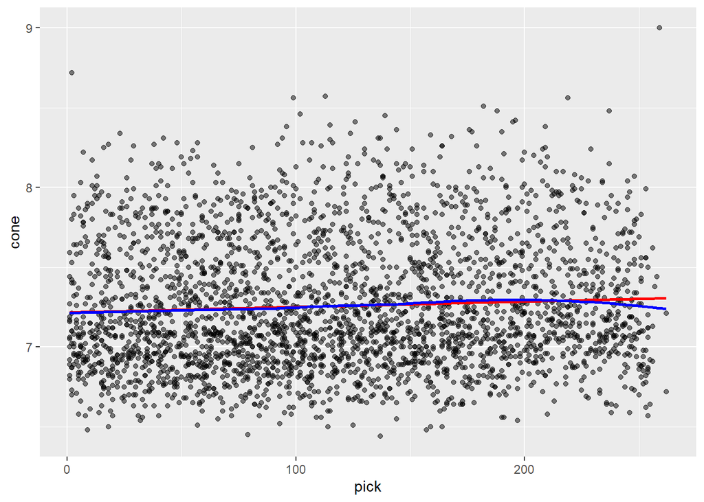

```r
merge_attrs %>% filter(!is.na(cone)) %>% ggplot(aes(x= pick,y= cone)) +
  geom_point(alpha=0.5) +
  geom_smooth(se=FALSE,method="lm",color="red") + geom_smooth(se=FALSE,method="loess",color="blue")
```

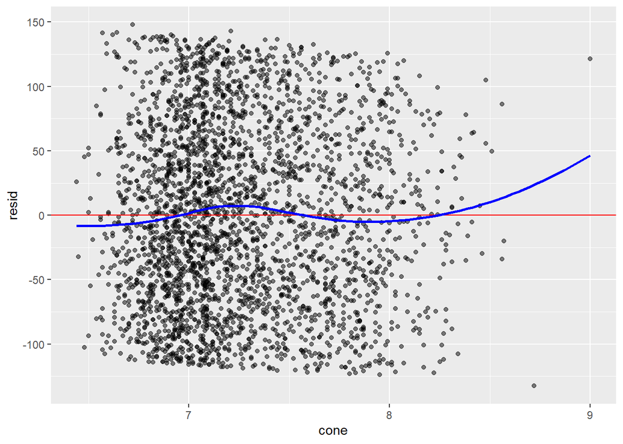

```r
c_lm = lm(pick ~ cone,data=merge_attrs %>% filter(!is.na(cone)))
merge_attrs %>% filter(!is.na(cone)) %>%
  add_residuals(c_lm) %>%
  add_predictions(c_lm) %>%
  ggplot(aes(x= cone,y=resid)) +
  geom_point(alpha=0.5) +
  geom_hline(yintercept = 0, color="red") +
  geom_smooth(se=FALSE,method="loess",color="blue")
```

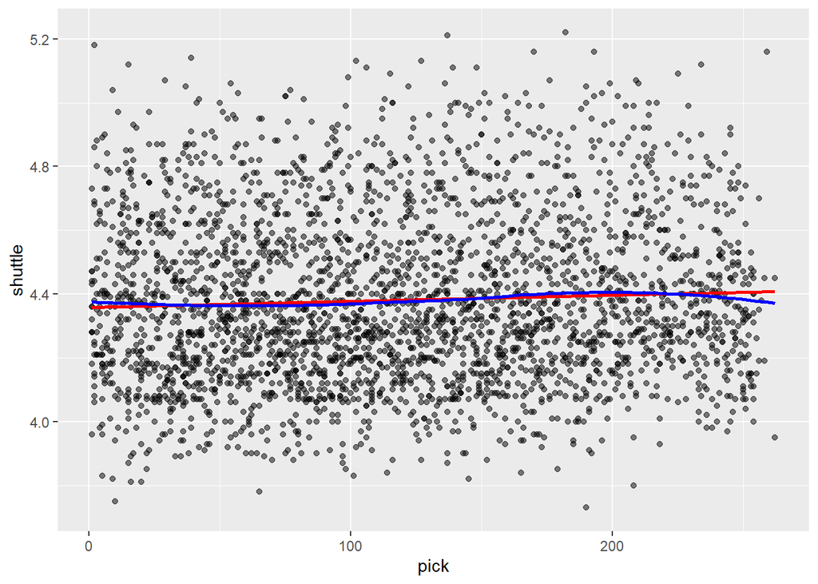

```r
merge_attrs %>% filter(!is.na(shuttle)) %>% ggplot(aes(x= pick,y= shuttle)) +
  geom_point(alpha=0.5) +
  geom_smooth(se=FALSE,method="lm",color="red") + geom_smooth(se=FALSE,method="loess",color="blue")
```

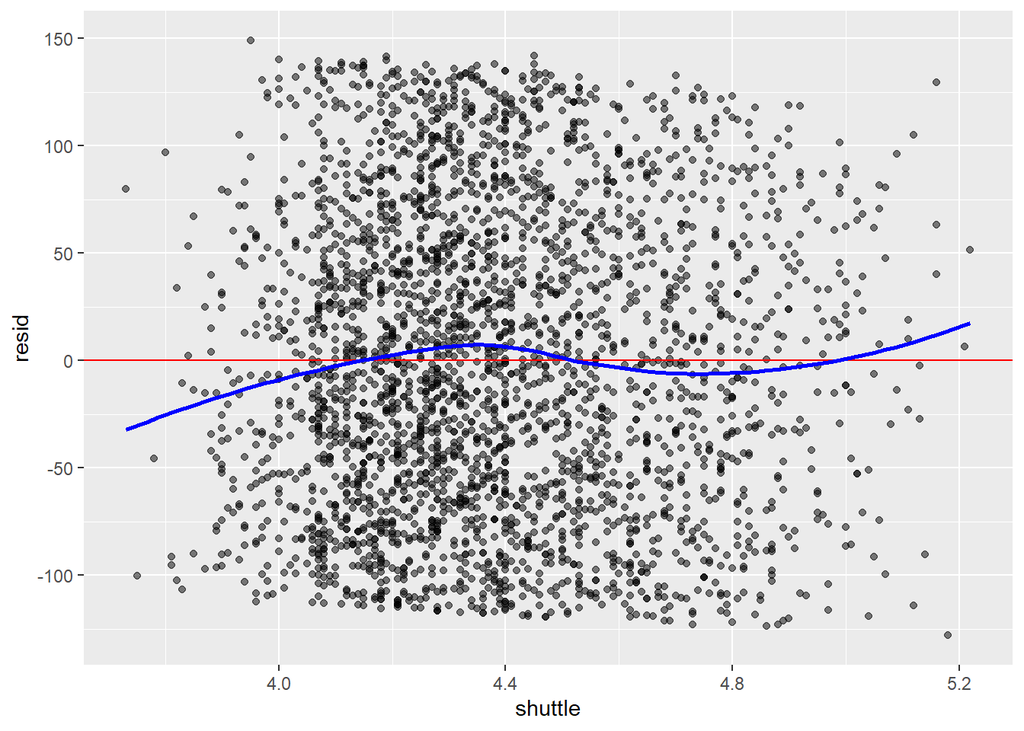

```r
s_lm = lm(pick ~ shuttle,data=merge_attrs %>% filter(!is.na(shuttle)))
merge_attrs %>% filter(!is.na(shuttle)) %>%
  add_residuals(s_lm) %>%
  add_predictions(s_lm) %>%
  ggplot(aes(x= shuttle,y=resid)) +
  geom_point(alpha=0.5) +
  geom_hline(yintercept = 0, color="red") +
  geom_smooth(se=FALSE,method="loess",color="blue")
```

# Research Question 2. Are there any specific draft positions that are more likely to produce successful players than others?

```r
#Inference on Proportions

success_threshold <- median(draft_data_clean$rush_yards, na.rm = TRUE)
draft_data_clean$successful_player <- ifelse(draft_data_clean$rush_yards > success_threshold, 1, 0)


success_proportion <- draft_data_clean %>%
  group_by(position) %>%
  summarise(
    proportion_success = mean(successful_player),
    n = n()
  )

print(success_proportion)
```

```
## # A tibble: 14 × 3
##    position proportion_success     n
##    <chr>                 <dbl> <int>
##  1 CB                  0.0290     69
##  2 DB                  0.0459    762
##  3 DE                  0.00283   706
##  4 DL                  0          24
##  5 DT                  0.0144    487
##  6 G                   0           1
##  7 ILB                 0          19
##  8 LB                  0.0126    795
##  9 NT                  0          80
## 10 OLB                 0          58
## 11 S                   0.0405     74
## 12 T                   0           1
## 13 TE                  0           1
## 14 WR                  0           1
```

> This part of the code defines a success criterion based on rushing yards and calculates the proportion of successful players in each position. It is instrumental in examining whether certain positions are more likely to yield successful players, thus addressing the latter part of your research question. By calculating these proportions, this analysis provides a statistical foundation to infer position-specific success rates, enhancing the understanding of how different positions correlate with the success rates of players in the NFL.

> Here I will dive in to the correlation between draft pick and success for the four main offensive skill positions in the NFL: Quarterback (QB), Running Back (RB), Wide Reciever (WR), and Tight End (TE). To create a metric to compute and compare success, I am utilizing fantasy points, a scoring system that is commonly used to calcuate “points” based on a player’s statistics. Below I evaluate if draft pick can be used to explain fantasy points using a linear regression model, while using a logarithmic transformation on fantasy points.

```r
draft_data = draft_data %>% replace(is.na(.), 0)
qb = draft_data %>%
  filter(position == "QB") %>%
  select(round, pick, position, pass_yards, pass_tds, pass_ints, rush_yards, rush_tds, probowls, allpro) %>%
  mutate(fantasy_points = pass_yards*0.25 + pass_tds*4 + pass_ints*-2 + rush_yards*0.1 + rush_tds*6) %>%
  mutate(
         log_fpoints = case_when(
           fantasy_points <= 0 ~ 0,
           fantasy_points != 0 ~ log(fantasy_points)))

rb = draft_data %>%
  filter(position == "RB") %>%
  select(round, pick, rush_yards, rush_tds, probowls, allpro, seasons_started) %>%
  mutate(fantasy_points = rush_yards*0.1 + rush_tds*6) %>%
  mutate(
         log_fpoints = case_when(
           fantasy_points <= 0 ~ 0,
           fantasy_points != 0 ~ log(fantasy_points)))

wr = draft_data %>%
  filter(position == "WR") %>%
  select(round, pick, rec_yards, rec_tds, receptions, probowls, allpro, seasons_started) %>%
  mutate(fantasy_points = receptions*0.5 + rec_yards*0.1 + rec_tds*6) %>%
  mutate(
         log_fpoints = case_when(
           fantasy_points <= 0 ~ 0,
           fantasy_points != 0 ~ log(fantasy_points)))


te = draft_data %>%
  filter(position == "TE") %>%
  select(round, pick, rec_yards, rec_tds, receptions, probowls, allpro, seasons_started) %>%
  mutate(fantasy_points = receptions*0.5 + rec_yards*0.1 + rec_tds*6) %>%
  mutate(
         log_fpoints = case_when(
           fantasy_points <= 0 ~ 0,
           fantasy_points != 0 ~ log(fantasy_points)))

qb_cor = cor(qb$pick, qb$log_fpoints)
qb_lm = lm(log_fpoints ~ pick, data = qb)


qb_plot = ggplot(qb, aes(x = pick, y = log_fpoints)) + geom_point() + geom_smooth(se = FALSE, method = "lm") + xlab("Draft Pick") + ylab("Fantasy Points (log scale)") + ggtitle("Quarterbacks (r = -0.64)")

rb_cor = cor(rb$pick, rb$log_fpoints)
rb_lm = lm(log_fpoints ~ pick, data = rb)


rb_plot = ggplot(rb, aes(x = pick, y = log_fpoints)) + geom_point() + geom_smooth(se = FALSE, method = "lm") + xlab("Draft Pick") + ylab("Fantasy Points (log scale)") + ggtitle("Running Backs (r = -0.61)")


wr_cor = cor(wr$pick, wr$log_fpoints)
wr_lm = lm(log_fpoints ~ pick, data = wr)


wr_plot = ggplot(wr, aes(x = pick, y = log_fpoints)) + geom_point() + geom_smooth(se = FALSE, method = "lm") + xlab("Draft Pick") + ylab("Fantasy Points (log scale)") + ggtitle("Wide Recievers (r = -0.60)")

te_cor = cor(te$pick, te$log_fpoints)
te_lm = lm(log_fpoints ~ pick, data = te)


te_plot = ggplot(te, aes(x = pick, y = log_fpoints)) + geom_point() + geom_smooth(se = FALSE, method = "lm") + xlab("Draft Pick") + ylab("Fantasy Points (log scale)") + ggtitle("Tight Ends (r = -0.56)")

tibble(qb_cor, rb_cor, wr_cor, te_cor)
```

```
## # A tibble: 1 × 4
##   qb_cor rb_cor wr_cor te_cor
##    <dbl>  <dbl>  <dbl>  <dbl>
## 1 -0.636 -0.606 -0.600 -0.561
```

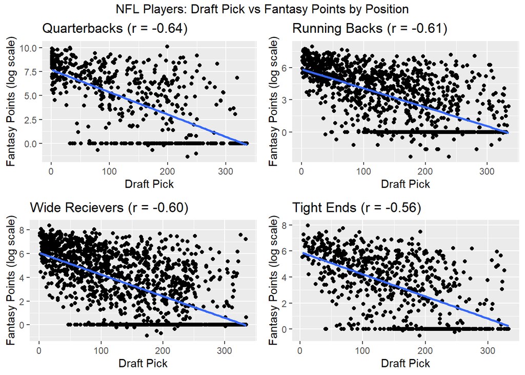

```r
grid.arrange(qb_plot, rb_plot, wr_plot, te_plot, top = textGrob("NFL Players: Draft Pick vs Fantasy Points by Position"))
```

> The graphs show a similar trend among all four positions: A moderate negative correlation between draft pick and log(fantasy points), indicating that a higher draft pick does seem to correlate with more success in the NFL.

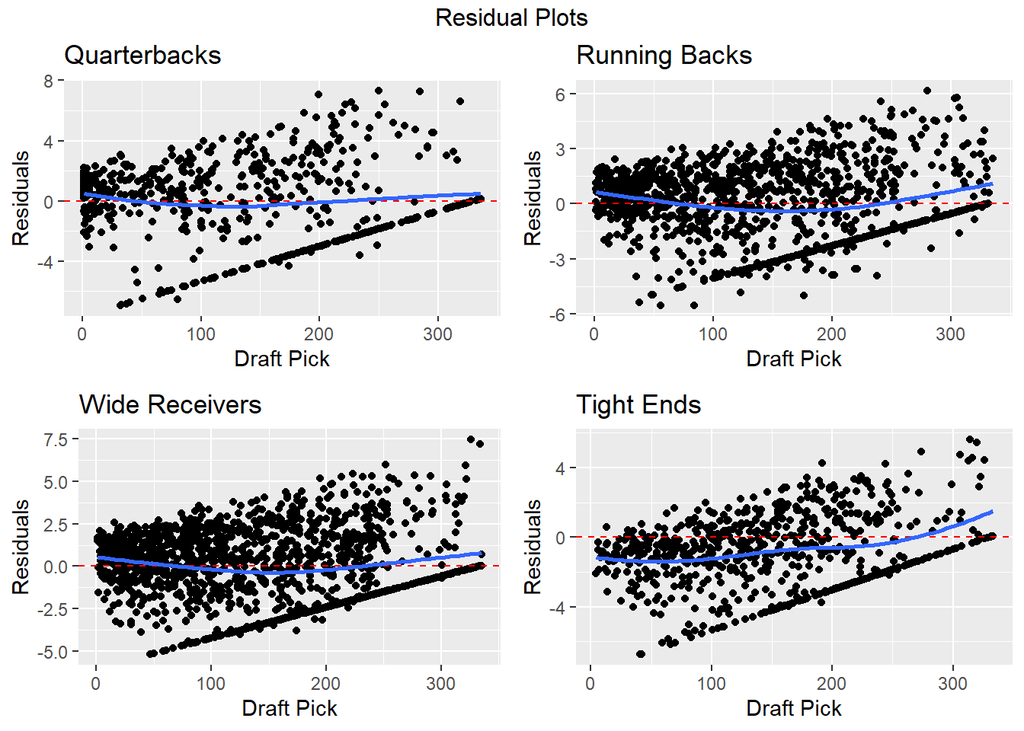

```r
qb = qb %>%
  add_residuals(qb_lm)

qb_resid = ggplot(qb, aes(x = pick, y = resid)) + geom_point() + geom_hline(yintercept = 0, color = "red", linetype = "dashed") + xlab("Draft Pick") + ylab("Residuals") + ggtitle("Quarterbacks") + geom_smooth(se=FALSE)

rb = rb %>%
  add_residuals(rb_lm)

rb_resid = ggplot(rb, aes(x = pick, y = resid)) + geom_point() + geom_hline(yintercept = 0, color = "red", linetype = "dashed") + xlab("Draft Pick") + ylab("Residuals") + ggtitle("Running Backs")+ geom_smooth(se=FALSE)

wr = wr %>%
  add_residuals(wr_lm)

wr_resid = ggplot(wr, aes(x = pick, y = resid)) + geom_point() + geom_hline(yintercept = 0, color = "red", linetype = "dashed") + xlab("Draft Pick") + ylab("Residuals") + ggtitle("Wide Receivers") + geom_smooth(se=FALSE)

te = te %>%
  add_residuals(qb_lm)

te_resid = ggplot(te, aes(x = pick, y = resid)) + geom_point() + geom_hline(yintercept = 0, color = "red", linetype = "dashed") + xlab("Draft Pick") + ylab("Residuals") + ggtitle("Tight Ends") + geom_smooth(se=FALSE)

grid.arrange(qb_resid, rb_resid, wr_resid, te_resid, top = textGrob("Residual Plots"))
```

> Research Question 3. Can we develop a predictive model to forecast a player’s NFL success based on their draft position and other relevant factors?

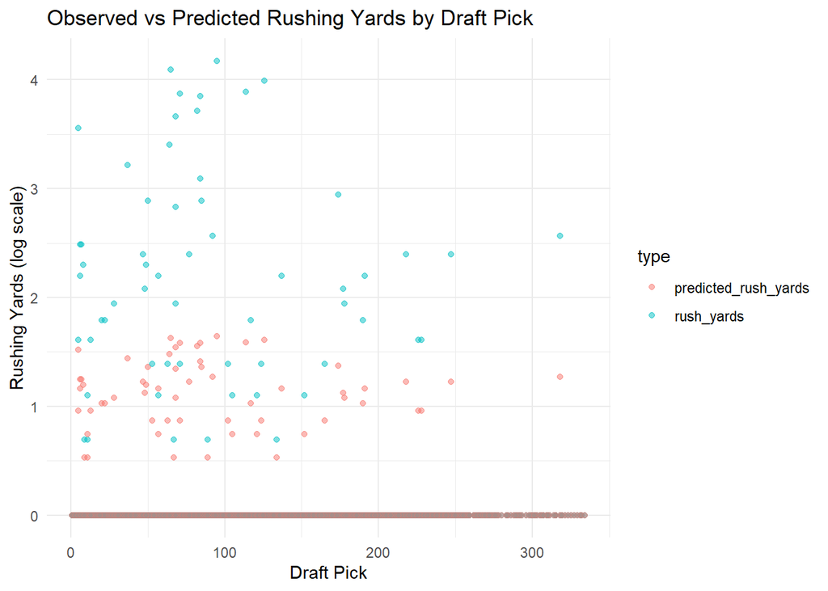

```r
small_value <- 1e-6


draft_data_clean <- draft_data_clean %>%
  mutate(
    rush_yards = ifelse(rush_yards <= 0, log1p(small_value), log1p(rush_yards)),
    predicted_rush_yards = ifelse(rush_yards <= 0, log1p(small_value), log1p(rush_yards))
  )


draft_data_clean <- na.omit(draft_data_clean)


plot_data <- draft_data_clean %>%
  select(pick, rush_yards, predicted_rush_yards) %>%
  pivot_longer(cols = c("rush_yards", "predicted_rush_yards"),
               names_to = "type",
               values_to = "yards")


ggplot(plot_data, aes(x = pick, y = yards, color = type)) +
  geom_point(alpha = 0.5) +
  theme_minimal() +
  labs(title = "Observed vs Predicted Rushing Yards by Draft Pick",
       x = "Draft Pick",
       y = "Rushing Yards (log scale)")
```

```r
# THIS CODE CHUNK CREATES THE DATA SET WE ARE GOING TO WORK WITH TO LOOK AT CORRELATIONS

combine = read_csv("../data/combine.csv")
players = read_csv("../data/draft_picks.csv")

combine = combine %>%
  select(draft_year, draft_team, draft_round, draft_ovr, player_name, pos, ht, wt, forty) %>%
  drop_na()

players = players %>%
  select(season, round, pick, team, pfr_player_name, position, age, hof, allpro, probowls) %>%
  drop_na() %>%
  filter(season >= 2000)

names(players) = c("season", "round", "pick", "team", "player", "position", "age", "HOF", "AP", "PB")
names(combine) = c("season", "team", "round", "pick", "player", "position", "height", "weight", "speed")

players = players %>%
  select(player, season, round, pick, position, age, HOF, AP, PB) %>%
  drop_na()

combine = combine %>%
  select(player, season, round, pick, position, height, weight, speed) %>%
  drop_na()

data = players %>%
  left_join(combine, by = c("player", "season", "round", "pick", "position")) %>%
  drop_na() %>%
  distinct() %>%
  filter(position == 'WR' | position == 'QB' | position == 'TE' | position == 'RB')

data = data %>%
  mutate(HOFscore = case_when(
    HOF == 'FALSE' ~ 0,
    HOF == 'TRUE' ~ 10
  )) %>%
  mutate(success_score = HOFscore + 3 * AP + PB) %>%
  select(everything(), -HOFscore)
```

> SIGNIFICANT RESULTS FOR QUARTERBACKS:

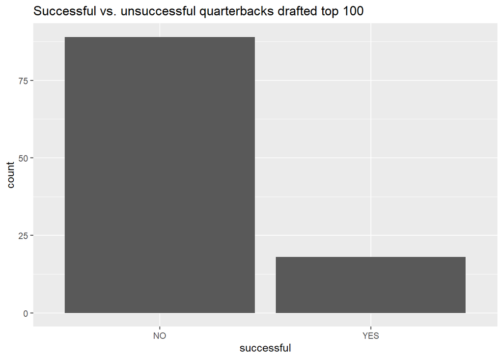

```r
# looking at proportions of successful qbs based on whether they were drafted top100 or not, and top32 or not
quarterbacks = data %>%
  filter(position == 'QB')

top100 = quarterbacks %>%
  filter(pick <= 100) %>%
  mutate(successful = case_when(
    success_score >= 3 ~ 'YES',
    success_score < 3 ~ 'NO'
  ))

notTop100 = quarterbacks %>%
  filter(pick > 100) %>%
  mutate(successful = case_when(
    success_score >= 3 ~ 'YES',
    success_score < 3 ~ 'NO'
  ))

ggplot(top100, aes(x = successful)) + geom_bar() + ggtitle("Successful vs. unsuccessful quarterbacks drafted top 100")
```

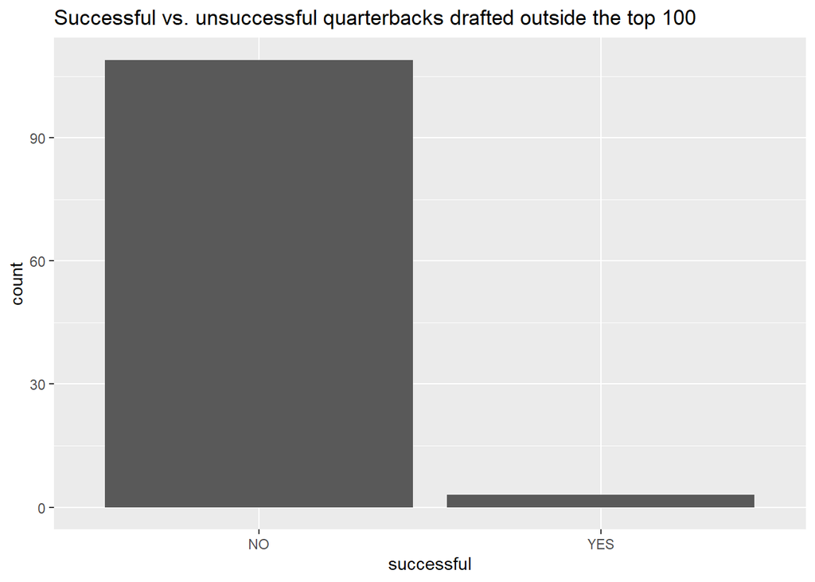

```r
ggplot(notTop100, aes(x = successful)) + geom_bar() + ggtitle("Successful vs. unsuccessful quarterbacks drafted outside the top 100")
```

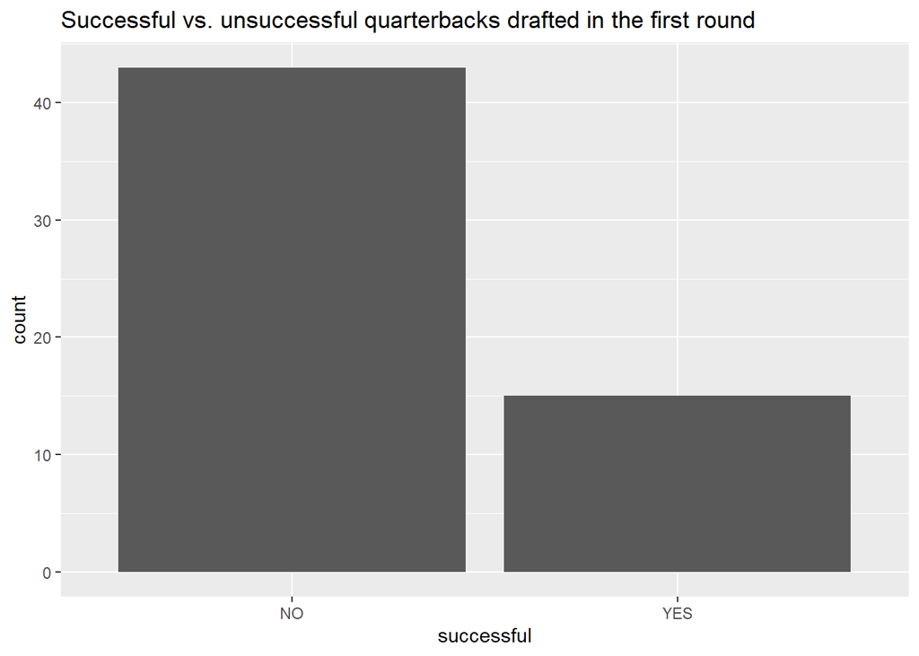

```r
firstRound = quarterbacks %>%
  filter(pick <= 32) %>%
  mutate(successful = case_when(
    success_score >= 3 ~ 'YES',
    success_score < 3 ~ 'NO'
  ))

notFirstRound = quarterbacks %>%
  filter(pick > 32) %>%
  mutate(successful = case_when(
    success_score >= 3 ~ 'YES',
    success_score < 3 ~ 'NO'
  ))

ggplot(firstRound, aes(x = successful)) + geom_bar() + ggtitle("Successful vs. unsuccessful quarterbacks drafted in the first round")
```

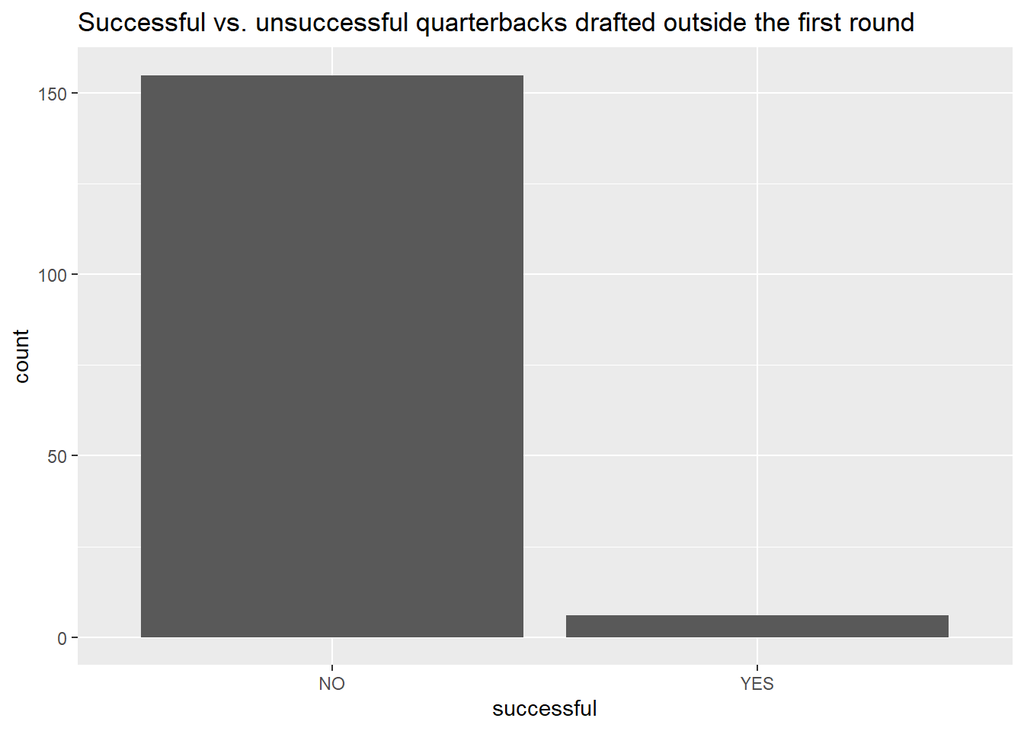

```r
ggplot(notFirstRound, aes(x = successful)) + geom_bar() + ggtitle("Successful vs. unsuccessful quarterbacks drafted outside the first round")
```

```r
#testing for significance for only first round qbs: Ho: Psuccess = 0.096, Ha: Psuccess > 0.096
#this can be considered binomial because there are only 2 options: successful or not, each qb's success is not determined by any other qb's success, sample size is pre-specified, and we are assuming each first round qb has the same probability of becoming successful

n = 57
p = 0.096
mean = n * p
sd = sqrt(mean * (1-p))

pval = (1 - pnorm(13, mean, sd))
pval
```

```
## [1] 0.0003562585
```

```r
n = 107
p = 0.096
mean = n * p
sd = sqrt(mean * (1-p))

pval = (1 - pnorm(17, mean, sd))
pval
```

```
## [1] 0.01362653
```

> A large portion of successful quarterbacks have been drafted earlier. Out of 219 quarterbacks, 21 have been considered successul (9.6%).

> There is extremely strong evidence (p value = 0.0004, one-sided binomial test) that in the long run a quarterback drafted in the first round is more likely to be successful than a quarterback not drafted in the first round.

> There is also strong evidence (p value = 0.014, one-sided binomial test) that in the long run a quarterback drafted in the top 100 picks is more likely to be successful than a quarterback not drafted in the top 100.

> SIGNIFICANT RESULTS FOR WIDE RECEIVERS:

```r
wr = data %>%
  filter(position == 'WR')

firstRoundWR = wr %>%
  filter(pick <= 32)

#ggplot(wr, aes(x = weight, y = success_score)) + geom_point() + geom_smooth(alpha = 0.3) + geom_hline(yintercept = 3)



x = firstRoundWR$weight
y = firstRoundWR$success_score

wr_weight_lm = lm(success_score ~ weight, firstRoundWR)
summary(wr_weight_lm)
```

```
##
## Call:
## lm(formula = success_score ~ weight, data = firstRoundWR)
##
## Residuals:
##     Min      1Q  Median      3Q     Max
## -5.6646 -2.3982 -0.7793  0.5666 19.4443
##
## Coefficients:
##              Estimate Std. Error t value Pr(>|t|)
## (Intercept) -20.46640    5.85753  -3.494 0.000770 ***
## weight        0.10888    0.02853   3.816 0.000262 ***
## ---
## Signif. codes:  0 '***' 0.001 '**' 0.01 '*' 0.05 '.' 0.1 ' ' 1
##
## Residual standard error: 4.129 on 82 degrees of freedom
## Multiple R-squared:  0.1508, Adjusted R-squared:  0.1405
## F-statistic: 14.56 on 1 and 82 DF,  p-value: 0.0002618
```

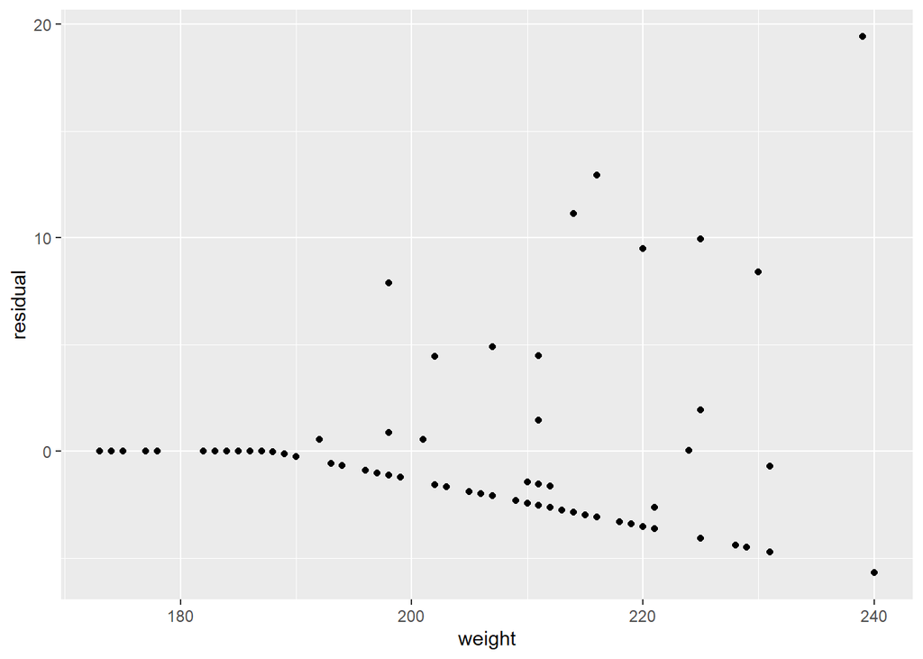

```r
firstRoundWR = firstRoundWR %>%
  mutate(predicted_success = -20.47 + .109 * weight, residual = case_when(
    predicted_success <= 0 ~ 0,
    predicted_success > 0 ~ success_score - predicted_success))

ggplot(firstRoundWR, aes(x = weight, y = residual)) + geom_point()
```

```r
sub200lbFRWR = firstRoundWR %>%
  filter(weight <= 200) %>%
  mutate(suc = case_when(
    success_score >= 3 ~ 'YES',
    success_score < 3 ~ 'NO'
  ))

above200lbFRWR = firstRoundWR %>%
  filter(weight > 200) %>%
  mutate(suc = case_when(
    success_score >= 3 ~ 'YES',
    success_score < 3 ~ 'NO'
  ))

firstRoundWR %>%
  filter(success_score >= 3) %>%
  print(n = Inf)
```

```
## # A tibble: 14 × 15
##    player      season round  pick position   age HOF      AP    PB height weight
##    <chr>        <dbl> <dbl> <dbl> <chr>    <dbl> <lgl> <dbl> <dbl> <chr>   <dbl>
##  1 Reggie Way…   2001     1    30 WR          22 FALSE     1     6 6-0       198
##  2 Andre John…   2003     1     3 WR          22 FALSE     2     7 6-2       230
##  3 Larry Fitz…   2004     1     3 WR          21 FALSE     1    11 6-3       225
##  4 Roddy White   2005     1    27 WR          23 FALSE     1     4 6-1       207
##  5 Calvin Joh…   2007     1     2 WR          21 TRUE      3     6 6-5       239
##  6 Demaryius …   2010     1    22 WR          22 FALSE     0     4 6-3       224
##  7 Dez Bryant    2010     1    24 WR          21 FALSE     1     3 6-2       225
##  8 A.J. Green    2011     1     4 WR          23 FALSE     0     7 6-4       211
##  9 Julio Jones   2011     1     6 WR          22 FALSE     2     7 6-3       220
## 10 DeAndre Ho…   2013     1    27 WR          21 FALSE     3     5 6-1       214
## 11 Cordarrell…   2013     1    29 WR          22 FALSE     4     4 6-2       216
## 12 Mike Evans    2014     1     7 WR          21 FALSE     0     4 6-5       231
## 13 Amari Coop…   2015     1     4 WR          21 FALSE     0     4 6-1       211
## 14 Justin Jef…   2020     1    22 WR          21 FALSE     1     3 6-1       202
## # ℹ 4 more variables: speed <dbl>, success_score <dbl>,
## #   predicted_success <dbl>, residual <dbl>
```

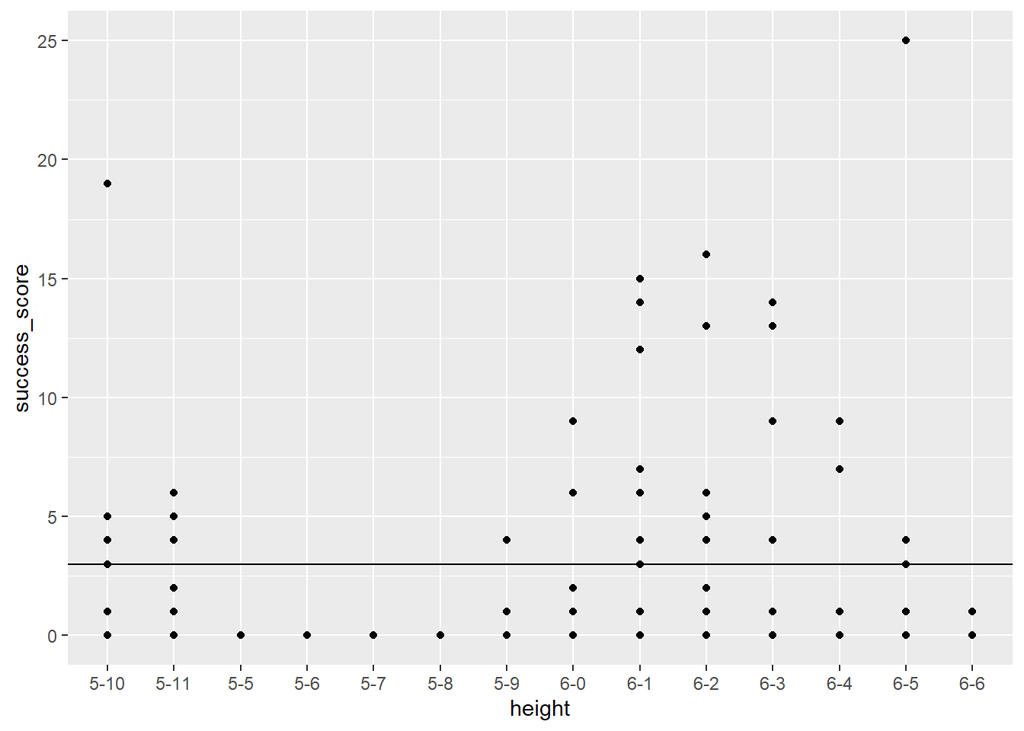

```r
ggplot(wr, aes(x = height, y = success_score)) + geom_point() + geom_smooth() + geom_hline(yintercept = 3)
```

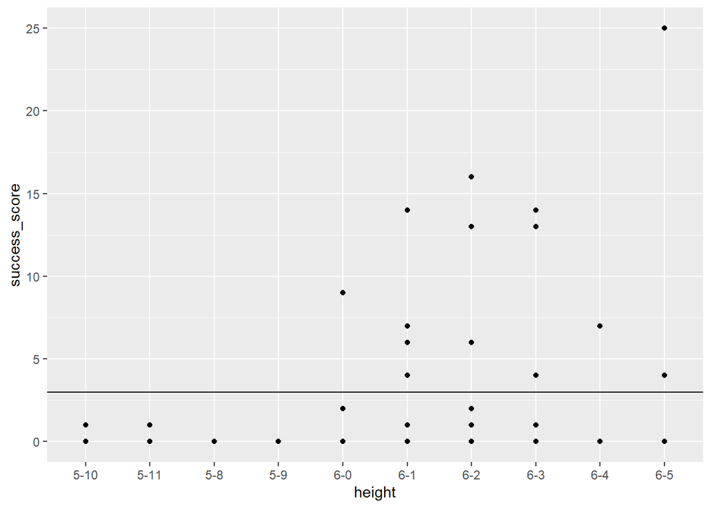

```r
ggplot(firstRoundWR, aes(x = height, y = success_score)) + geom_point() + geom_smooth() + geom_hline(yintercept = 3)
```

```r
nrow(sub200lbFRWR)
```

```
## [1] 35
```

```r
nrow(above200lbFRWR)
```

```
## [1] 49
```

> Out of 587 wide receivers, 35 have been considered successful (6%)